# AI Foundations: AII 600

Estimation, data quality, and unsupervised patterns

Vadim Sokolov

George Mason University

Fall 2026

[Course Page](https://vsokolov.org/courses/600.html), [Slides](https://www.dropbox.com/scl/fo/lkarctbkv5ajttfpsjwmn/ADCbdXqaUV0ElNsN2SV9Wtk?rlkey=09s9z5yejmytljge9kdq88wu4&dl=0)

## Probability and Making Decision

The secretary problem: also called the matching or marriage problem.

- You will see $T$ items, one at a time, from a distribution of types $F(x)$.
- You want the maximum. After you pass, you cannot go back.
- $t$ is the slot you are in: $t=1,\ldots,T$.
- Strategy: skip a prefix, then take the next candidate who is better than everyone you have seen.
- For large $T$ the prefix is a fraction $1/e$ of the list:
  $$\frac{1}{e} \approx 0.368.$$

## A Simple Example

Say I have a budget to consider $T=10$ candidates, and they have the following scores (which I do not know)

```
    1  7  4  5  3  8  10  3  0  11
```

I decide to screen 3 candidates before making a decision.

- My best candidate from the screening pool is 7
- Next is 5 –> dump
- Next is 3 –> dump
- Next is 8 –> accept

## Probability and Decision - Strategy

What’s your **best strategy**?

- Turns out its insensitive to the choice of distribution.
- Although there is the random sample i.i.d. assumption lurking.
- You’ll not doubt get married between $18$ and $60$. **Waiting** $\frac{1}{e}$ along this sequence gets you to age $33$. Then, pick the next best person!

## If you take the best so far at $t$

- $T$ is the length of the list. Ten candidates, $T=10$.
- $t$ is the slot you are looking at. In the example you accepted at $t=6$.
- Best so far at $t$ means better than the first $t-1$. Candidate 8, after a screen whose best was 7.
- The overall best is equally likely to sit in any of the $T$ positions.
- Overall best implies best of the first $t$, so
  $$P(\text{overall best}\mid \text{best so far at }t)
  = \frac{P(\text{overall best})}{P(\text{best so far at }t)}
  = \frac{1/T}{1/t}
  = \frac{t}{T}.$$
- Take that candidate and you win with probability $t/T$. In the example, $6/10$.
- If $t$ is the overall best, it is automatically the best of the first $t$. The earlier ranks do not change the ratio.
- Being the best of the first $t$ has probability $1/t$.

## Success under the $r$-rule

- Reject the first $r$. Then take the first later candidate who is the best so far.
- You win only if you take the overall best. Put that person at slot $a$. Probability $1/T$.
- You never take them if $a\le r$: still screening.
- If $a>r$ you still miss them whenever someone in $r+1,\ldots,a-1$ was the best so far. That happens when the best of the first $a-1$ sits after $r$. You would have taken that person and gone home.

## Success under the $r$-rule

- So you need the best of the first $a-1$ to sit in the skipped prefix. Those $a-1$ ranks are in random order, so their max is equally likely in any of those $a-1$ slots:
  $$\frac{r}{a-1}.$$
- In the example, $r=3$. If the overall best is at $a=6$, the first five are $1,7,4,5,3$. Their max is $7$, in the prefix. Chance $3/5$.
- Denominator $a-1$, not $a$: slot $a$ is already the overall best. The comparison is among the others.
  $$P(\text{success})
  = \frac{1}{T}\sum_{a=r+1}^{T}\frac{r}{a-1}
  = \frac{r}{T}\sum_{b=r}^{T-1}\frac{1}{b}.$$
- Need $r\ge 1$. If $r=0$ you take the first candidate and win with probability $1/T$.
- If nobody after $r$ is the best so far, you take the last one. That path never wins.

## Then $r=T/e$

- For large $T$ the harmonic sum is a log:
  $$\frac{r}{T}\sum_{b=r}^{T-1}\frac{1}{b}
  \approx \frac{r}{T}\log\frac{T}{r}.$$
- Differentiate in $r$ and set the derivative to zero:
  $$\frac{1}{T}\log\frac{T}{r}-\frac{1}{T}=0
  \qquad\Rightarrow\qquad
  r=\frac{T}{e}.$$
- Plug back in:
  $$P(\text{success})\approx\frac{1}{e}\log e=\frac{1}{e}.$$
- About $37$ percent for large $T$, approached from above.
- This $r$ is best among skip-then-take-the-next-best-so-far rules. The Bellman step says the optimum is of that form.
- The distribution of the scores never entered. Only the random order of the ranks.

## $1/e$ in a sample of $1000$

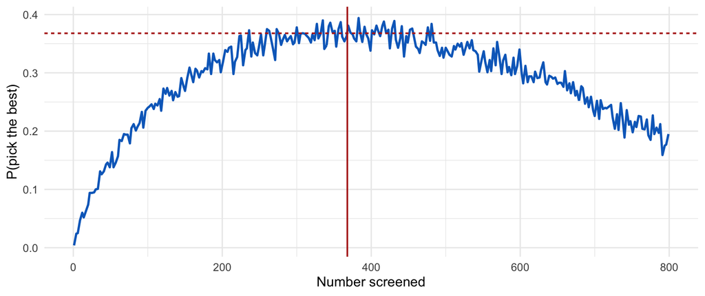

The peak is near $T/e$ and height $1/e$ (Monte Carlo, so the top wiggles).

- Average quality, not shown, peaks much earlier.
- Maximizing the chance of the absolute best is not the same as maximizing expected rank.

## Decision Trees

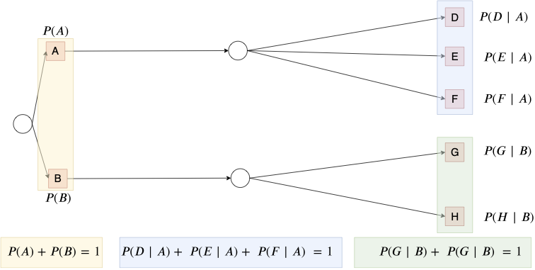

Decision Tree

## Catastrophe Modeling

You live in a house that is somewhat **prone to mud slides**.

- Each rainy season there is a **1% chance** of a mud slide occurring.
- You estimate that a mud slide would do **$1 million** in damage.
- You have the **option** of building a retaining wall that would help reduce the chance of a devastating mud slide. The wall costs $40,000 to build, and if the slide occurs, the wall will hold with a 95% probability.
- You also have the **option** of a Geologist’s opinion.

**Should you build the wall?** **Should you use the Geologist’s Test and Bayes Rule?**

## Decision Tree Setup

Let’s formally solve this as follows:

- **Build a decision tree**.
- The tree will list the probabilities at each node. It will also list any costs there are you going down a particular branch.
- Finally, it will list the expected cost of going down each branch, so we can see which one has the better risk/reward characteristics.

There’s also the possibility of a further test to see if the wall will hold.

## Decision Tree

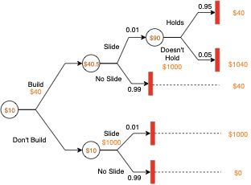

Mudslide Decision Tree

## Testing Option

Let’s include the **testing option**

- You also have the option of having a test done to determine whether or not a slide will occur in your location.
- The test costs $3000 and has the following accuracies.
  $$P(T \mid \text{Slide}) = 0.90 \quad \text{and} \quad P(\bar{T} \mid \text{No Slide}) = 0.85$$

If you choose the test, then should you build the wall?

## Bayes Rule for Testing

**Bayes Rule** is as follows:

- The initial prior probabilities are
  $$P(\text{Slide}) = 0.01 \quad \text{and} \quad P(\text{No Slide}) = 0.99$$
- Therefore
  $$\begin{align*}
  P(T) &= P(T \mid \text{Slide}) P(\text{Slide}) + P(T \mid \text{No Slide}) P(\text{No Slide}) \\
  P(T)&= 0.90 \times 0.01 + 0.15 \times 0.99 = 0.1575
  \end{align*}$$

We’ll use this to find our optimal course of action.

## Bayes Probabilities - Positive Test

The Bayes probability given a positive test is
$$\begin{align*}
P(\text{Slide} \mid T) &= \frac{P(T \mid \text{Slide}) P(\text{Slide})}{P(T)} \\
&= \frac{0.90 \times 0.01}{0.1575} = 0.0571
\end{align*}$$

## Bayes Probabilities - Negative Test

The Bayes probability given a negative test is
$$\begin{align*}
P(\text{Slide} \mid \bar{T}) &= \frac{P(\bar{T} \mid \text{Slide}) P(\text{Slide})}{P(\bar{T})} \\
&= \frac{0.1 \times 0.01}{0.8425} \\
&=0.001187
\end{align*}$$

Compare this to the initial base rate of a $1$% chance of having a mud slide.

## Probability Lose Everything - Without Testing

**You build the wall without testing, what’s the probability that you lose everything?**

With the given situation, there is one path (or sequence of events and decisions) that leads to losing everything:

1. Build without testing (given)
2. Slide ($0.01$)
3. Doesn’t hold ($0.05$)

$$P(\text{losing everything} \mid \text{build w/o testing}) = 0.01 \times 0.05 = 0.0005$$

## Probability Lose Everything - With Testing

**You choose the test, what’s the probability that you’ll lose everything?**

There are two paths that lead to losing everything:

1. **First Path:** There are three things that have to happen to lose everything Test +ve ($P=0.1575$), Build, Slide ($P= 0.0571$), Doesn’t Hold ($P=0.05$)
2. **Second Path:** Now you lose everything if Test -ve ($P=0.8425$), Don’t Build, Slide given negative ($P=0.001187$)

## Conditional Probabilities

For the **first** path
$$P(\text{first path}) = 0.1575 \times 0.0571 \times 0.05 = 0.00045$$

For the **second** path
$$P(\text{second path}) = 0.8425 \times 0.001187 = 0.00101$$

Hence putting it all together
$$P(\text{losing everything} \mid \text{testing}) = 0.00045 + 0.00101 = 0.00146$$

## Risk and Reward

**Risk-Return Trade-off**

| Choice | Expected Cost | Risk | P |
| --- | --- | --- | --- |
| Don’t Build | $10,000 | 0.01 | 1 in 100 |
| Build w/o testing | $40,500 | 0.0005 | 1 in 2000 |
| Test | $10,760 | 0.00146 | 1 in 700 |

Expected Cost: Fee + Build + Loss

Expected cost: $3 + 40\times 0.1575+ 1000\times 0.00146$ or $10,760

**What do you choose?**

# Estimation

## Three situations

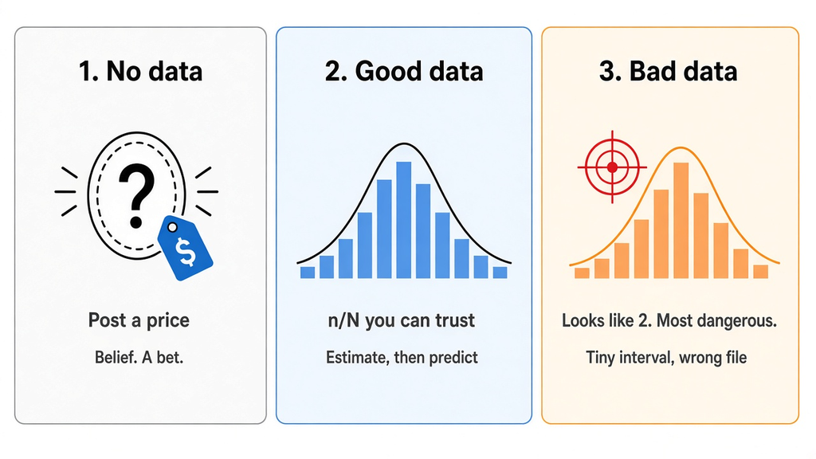

## Map for the hour

- 1. No data
- No sample. You post a price.
- Coin, a bet, coherence.
- Secretary. Mudslide prior.
- 2. Good data
- n/N you can trust.
- More of the same sample, tighter around the right number.
- Alpha particles: the worked example.
- 3. Bad data
- Looks like 2. Most dangerous.
- Tiny interval, wrong sample.
- Literary Digest, WHI, Spirit.
- The trap is mixing 2 and 3. The machine sounds like 2.

## 1. No data

- No sample from the process you will decide for.
- Probability is a language for uncertainty. Usually lack of information, not a property of the coin.
- Operational answer: a price you would bet at.
- The number has to cohere. Otherwise someone books you.

## How many coins in my pocket?

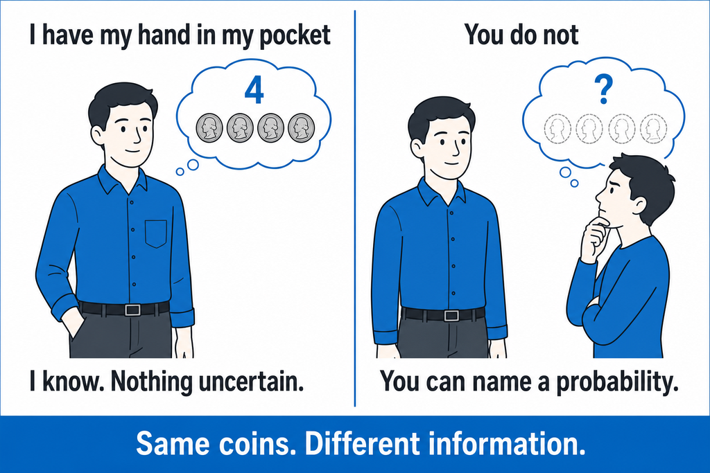

Probability is a property of what you know.

## Probability as a bet

- Ramsey and de Finetti: your probability is the odds at which you will bet.
- de Finetti: “Probability does not exist.” Uncertainty is personal. It is not mass.
- Different news, a trade, a price.
- 2016: bookmakers posting prices on the same event. Those prices are probabilities.
- This course uses both languages. Frequency is how we talk about data. The organizing view is belief, updated by evidence.

[figure not shown]

Presidential odds, 2016

## The coin is risk

- Most people agree on $P(\text{Heads})=1/2$. We elicit that number as a willingness to play.
- Will you pay $1 to receive $2 if the coin lands tails, and $0 if it lands heads? If you are indifferent, your $P(\text{Tails})$ is $1/2$.
- Probability and payoff arrive together. You cannot separate them.
- Litowitz asks the same question, then raises the payoff. Pay $1 for a fair coin that pays $2 on heads. Most people pause. Make it $3 on heads. Almost everyone says yes.
- We know the possibilities and we know the odds, fifty-fifty. That is risk.
- The mudslide tree was the same object: $0.01$ from historical seasons, $0.95$ treated as known.

## The odds are not posted

- Often you will decide on something that does not look like a coin. A career, which model to ship, whether the merger closes.
- You know the possibilities and not the probabilities. That is ambiguity, not risk: Ellsberg’s second urn.
- Knight called the same contrast uncertainty. That is the word Litowitz used.
- Sometimes you do not even know the possibilities. Then you are past Ellsberg.
- The tools for the coin do not transfer.
- Three bad moves: freeze, pretend the odds are knowable, or hand the decision to a machine that sounds sure.
- The machine is superb at the coin. The rest stay yours.
- The move that still works: a strong provisional view, name what would change your mind, run the cheapest experiment, update.
- Stay the author of the decision. That is Bayes as a habit, not a formula.

[Litowitz, Fortune, 15 September 2026](https://fortune.com/2026/09/15/adaptability-quotient-citadel-magnetar-alec-litowitz/). Opening of *The Adaptability Quotient*.

## Dutch book

[figure not shown]

- Coherence means no Dutch book exists. In finance that is no-arbitrage.
- The leak is $P(A)+P(\bar A)=0.9\neq 1$.

## Kolmogorov’s axioms

Coherence forces the same rules Kolmogorov wrote down.

1. Non-negativity: $P(A)\ge 0$
2. Normalization: $P(\Omega)=1$
3. Additivity: if $A$ and $B$ cannot both happen, $P(A\text{ or }B)=P(A)+P(B)$

The complement rule $P(A)+P(\bar A)=1$ is 2 and 3 together. Violate any of them and someone can lock in a loss.

[figure not shown]

## How do we estimate a probability?

- Assigning the number is the hard part.
- No data: a price you would bet at.
- Good data: a long-run frequency from the process you will decide for.
- Bad data: same plot, wrong process. Looks trustworthy. That is the dangerous one.

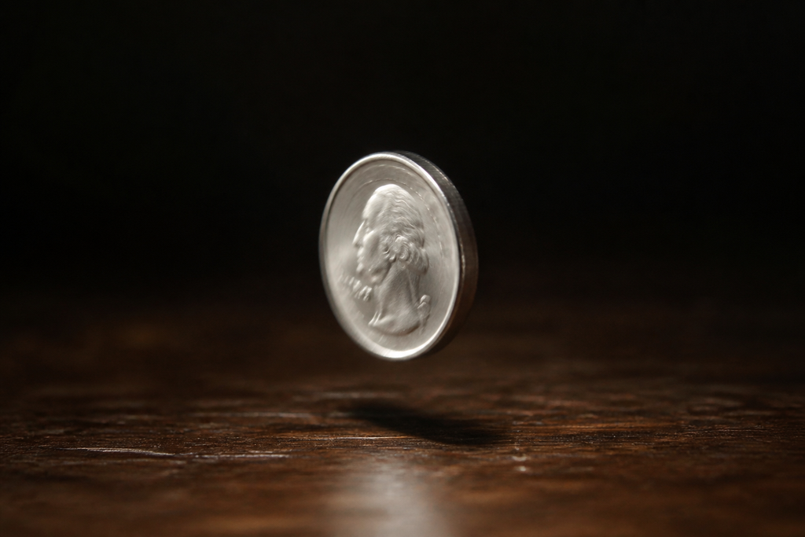

## 2. Good data

- A sample from the process you will decide for.
- Then you estimate: n/N, a mean, a Poisson $\lambda$.
- Trust in the usual sense: more good data, smaller variance around the right number.
- Frequency, then a sampling distribution. Alpha particles after the warning.

## Frequency

- Event $A$ is heads.
- Each grey path is one sequence of tosses. The blue path is one of them. The red line is $1/2$.

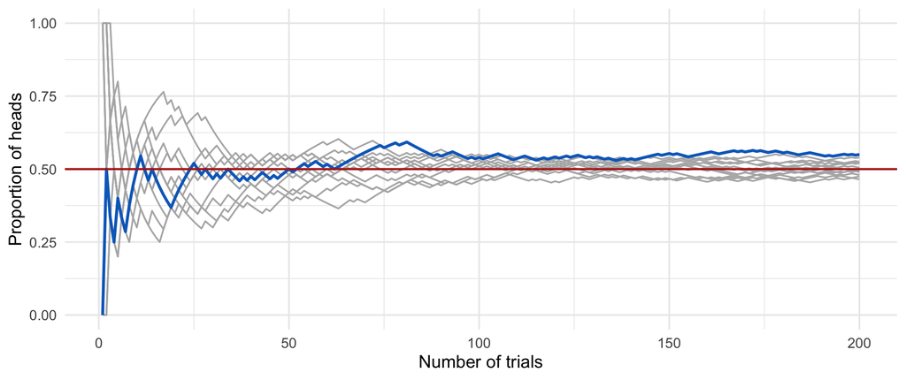

As $N$ grows, $n/N$ settles near $1/2$.

- That is the law of large numbers.
- von Mises wrote the limit as the definition:
  $$P(\text{Heads}) = \lim_{N \to \infty} \frac{n}{N}.$$

## Fitting a probability law

- Fit a Poisson or a Normal to observed data.
- Most laws depend on a few parameters: $\lambda$, or $\mu$ and $\sigma$.
- Estimate those from the sample. Then the distribution is specified.
- Then ask whether the fit is any good. Later.

## 3. Bad data

- Same shape as 2: rows, a histogram, a tight number.
- Blue is the sample. Orange is the law you fit. They already miss.
- The red target is the population you will decide for.
- Most dangerous because it looks like good data. Tiny interval, wrong sample.

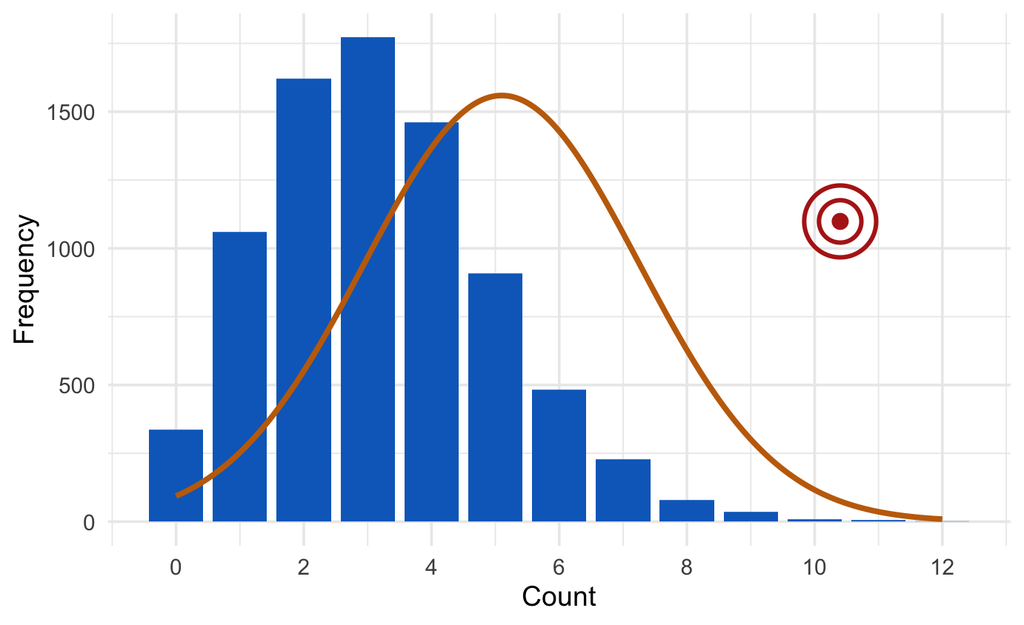

- Bias, not variance. We name this after sampling distributions: Literary Digest, WHI.
- Wrong law is the same trap: a tight Normal on the sample, a crash the model called impossible.

## The 1987 crash

- October 1987: S&P 500 dropped $-21.76\%$.
- Prior monthly returns: mean $1.2\%$, volatility $4.3\%$.
- The model fitted to earlier months: $X \sim N(0.012, 0.043^2)$.
- Standardize:
  $$Z = \frac{-0.2176 - 0.012}{0.043} = -5.34.$$
- A 5-sigma month. Under that Normal, $P(Z < -5.34) \approx 4.6 \times 10^{-8}$.

## The 1987 crash: the model

- We assumed returns are Normal. The middle of the histogram looks like 2.
- The tails are not. Extreme months happen. The crash is one of them.
- Same picture as the orange curve: a law fitted to the sample, a target the law cannot see.
- Week 1 computed the z-score. The lesson here is the assumption.

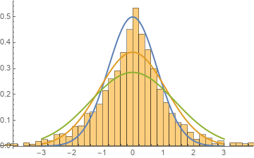

S&P 500 returns vs Normal

## The limit is not always a method

- Same plot as 2: $n/N$ settling toward a number. That is what makes 3 dangerous.
- The von Mises limit needs an infinite sequence of repeatable trials. You never observe it.
- Ville pointed this out. Bernoulli’s workable version is the finite ratio $n/N$ in the experiment you actually ran.
- It requires the same conditions. Change the coin, and the number changes.
- Blue is fair. Orange is $P(\text{Heads})=0.7$. Same $N$. Two different samples. Two different limits.

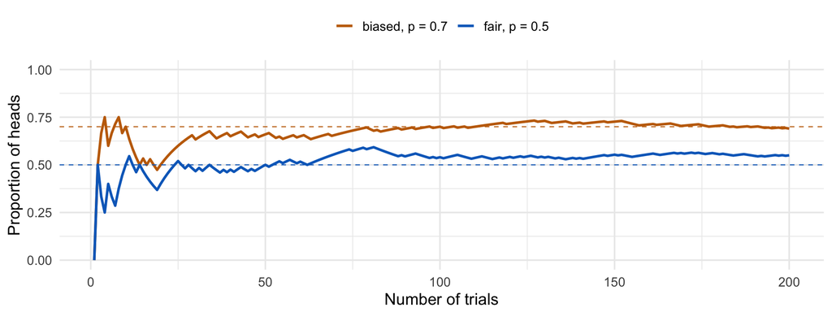

## Data-driven AI

- Modern AI is data-driven. The rest of the course is this approach: estimate from samples, then predict.
- A model trained on a limited sample is a frequency from that sample. The interval can be tiny around the wrong number.
- Very common in modern AI: confident when it should not be. The machine sounds sure. The sample was not the population.

## Data is a currency

- Self-driving is sold as a data race: the fleet that logs the most miles trains the better driver. Tesla’s pitch. Waymo’s counter: unsupervised miles are not the same as a human still in the seat.
- Data sells. Spirit Airlines, in bankruptcy in 2026, auctioned an operational archive. Google’s bid was $10 million: emails, chats, operations, for AI.
- The named passenger list was carved out of that Google deal. The estate kept the right to sell it to travel buyers.
- [Ars Technica, September 2026](https://arstechnica.com/tech-policy/2026/09/panic-builds-over-bankrupt-spirits-looming-data-sale-to-google/).

## From posting a price to estimating one

- Whenever we have a sample we should estimate from it.
- First a pattern with no named law: correlation. Two series, one number $r$.
- Then a law with a named parameter. The alpha counts: we estimate $\lambda$ in the open.
- Good data if the sample is from the process you will decide for. Bad data is the standing risk: same formulas, wrong population.
- The mudslide $0.01$ was a frequency from historical data, then treated as known.
- Working mechanism after the pattern: frequency. $n/N$, likelihood, sampling distributions.

# Unsupervised patterns

## Why Pattern Matching?

- Traditional approach: estimating parameters when functional form is known
  - Linear relationships (Earth-shape example)
  - Multiplicative relationships (Newton’s $F=ma$)
- Modern challenge: relationship itself is unknown
  - Human behavior, natural language
  - Complex, non-mathematical relationships
- Pattern matching: identifying recurring sequences, relationships, or structures
  - Like finding puzzle pieces that complete a picture

## Early Example: Mammography

Albert Solomon (1913)

- German surgeon, pioneer of X-ray imaging
- “Contributions to the Pathology and Clinic of Breast Cancers”
- First to recognize calcium deposits-cancer association

Challenges

- Subjective visual assessment
- Prone to errors in dense breasts
- Subtle abnormalities easily missed

Pattern recognition

- Dense tissue areas (masses)
- Small white calcium deposits (microcalcifications)

Impact

- Foundation for mammography screening
- Saved countless lives
- Molecular mechanisms still not fully understood

## Feynman on Pattern Matching

**Chess Analogy**

“Let’s say a chess game. And you don’t know the rules… you try to figure out what the rules are… You might discover that when there’s only one bishop around on the board, that the bishop maintains its color. Later on you might discover the law for the bishop is that it moves on a diagonal…”

- Experts develop pattern recognition abilities
- Chess players don’t calculate every move
- They recognize advantageous patterns
- Skill transfers to other domains

## Machine vs Human Intelligence

**Feynman on AI**

“When we make a bird, the airplanes don’t fly like a bird… It’s different, right? So, there’s no question that the later machines are not going to think like people think… they’re not going to do arithmetic the same way as we do arithmetic, but they’ll do it better.”

**Evolution in Chess:**

- 1996: Computers stronger than grandmasters
- AlphaZero: Self-learning through competition
- Neural networks learn features vs human heuristics
- Preference for initiative, speed, momentum over material

## Correlations: Simplest Pattern Matching

**Correlation coefficient**: measures strength of linear relationship

$$r = \frac{\text{cov}(X,Y)}{\sqrt{\text{var}(X)} \sqrt{\text{var}(Y)}}$$

Range: $-1 \leq r \leq 1$

**Applications:**

- Financial market relationships
- Portfolio diversification
- Risk assessment

## Google Stock Example

```r
goog = read.csv("data/GOOG2019.csv")
rgoog = goog$Adj.Close[2:251]/goog$Adj.Close[1:250] - 1
sp = read.csv("data/SP2019.csv");   rsp = sp$Adj.Close[2:251]/sp$Adj.Close[1:250] - 1
plot(rgoog, rsp, col="lightblue", pch=21, bg="grey", xlab="GOOG return", ylab="SP500 return")
```

```r
var_goog = mean((rgoog - mean(rgoog))^2)
var_sp = mean((rsp - mean(rsp))^2)
cov = mean((rgoog - mean(rgoog))*(rsp - mean(rsp)))
cor = cov/(sqrt(var_goog)*sqrt(var_sp))
```

[figure not shown]

## Unsupervised Learning: Election Forecasting

**2012 Obama Election Prediction**

- Goal: predict probability of Obama winning
- Data: polling data across 50 states + DC
- Method: Bayesian simulation with Dirichlet distribution
- Technique: Monte Carlo simulation (10,000 runs)

## Loading the data and aggregating it by state.

```r
library(plyr)
# Source: "http://www.electoral-vote.com/evp2012/Pres/pres_polls.csv"
election.2012 = read.csv("data/pres_polls.csv")
# Remove a pollster: elect2012 <- election.2012[!grepl('Rasmussen', election.2012$Pollster),]
elect2012 <- election.2012
# Aggregrate the data
elect2012 <- ddply(elect2012, .(state), subset, Day == max(Day))
elect2012 <- ddply(elect2012, .(state), summarise, R.pct = mean(GOP), O.pct = mean(Dem), EV = mean(EV))
```

## Display the data

```r
knitr::kable(elect2012[1:25,], caption = "Election 2012 Data",longtable=TRUE)
knitr::kable(elect2012[26:51,], caption = "Election 2012 Data",longtable=TRUE)
```

Election 2012 Data

| state | R.pct | O.pct | EV |
| --- | --- | --- | --- |
| Alabama | 61 | 38 | 9 |
| Alaska | 55 | 42 | 3 |
| Arizona | 54 | 44 | 11 |
| Arkansas | 61 | 37 | 6 |
| California | 38 | 59 | 55 |
| Colorado | 47 | 51 | 9 |
| Connecticut | 40 | 58 | 7 |
| D.C. | 7 | 91 | 3 |
| Delaware | 40 | 59 | 3 |
| Florida | 49 | 50 | 29 |
| Georgia | 53 | 45 | 16 |
| Hawaii | 28 | 71 | 4 |
| Idaho | 65 | 33 | 4 |
| Illinois | 41 | 57 | 20 |
| Indiana | 54 | 44 | 11 |
| Iowa | 47 | 52 | 6 |
| Kansas | 60 | 38 | 6 |
| Kentucky | 61 | 38 | 8 |
| Louisiana | 58 | 41 | 8 |
| Maine | 41 | 56 | 4 |
| Maryland | 37 | 62 | 10 |
| Massachusetts | 38 | 61 | 11 |
| Michigan | 45 | 54 | 16 |
| Minnesota | 45 | 53 | 10 |
| Mississippi | 56 | 44 | 6 |

Election 2012 Data

|  | state | R.pct | O.pct | EV |
| --- | --- | --- | --- | --- |
| 26 | Missouri | 54 | 44 | 10 |
| 27 | Montana | 55 | 41 | 3 |
| 28 | Nebraska | 61 | 38 | 5 |
| 29 | Nevada | 46 | 52 | 6 |
| 30 | New Hampshire | 46 | 52 | 4 |
| 31 | New Jersey | 41 | 58 | 14 |
| 32 | New Mexico | 43 | 53 | 5 |
| 33 | New York | 36 | 63 | 29 |
| 34 | North Carolina | 51 | 48 | 15 |
| 35 | North Dakota | 59 | 39 | 3 |
| 36 | Ohio | 48 | 50 | 18 |
| 37 | Oklahoma | 67 | 33 | 7 |
| 38 | Oregon | 43 | 54 | 7 |
| 39 | Pennsylvania | 47 | 52 | 20 |
| 40 | Rhode Island | 36 | 63 | 4 |
| 41 | South Carolina | 55 | 44 | 9 |
| 42 | South Dakota | 58 | 40 | 3 |
| 43 | Tennessee | 60 | 39 | 11 |
| 44 | Texas | 57 | 41 | 38 |
| 45 | Utah | 73 | 25 | 6 |
| 46 | Vermont | 31 | 67 | 3 |
| 47 | Virginia | 48 | 51 | 13 |
| 48 | Washington | 42 | 56 | 12 |
| 49 | West Virginia | 62 | 36 | 5 |
| 50 | Wisconsin | 46 | 53 | 10 |
| 51 | Wyoming | 69 | 28 | 3 |

## Run the simulation and plot probabilities by state.

```r
suppressMessages(library(MCMCpack))
prob.Obama <- function(mydata) {
    p <- rdirichlet(1000, 500 * c(mydata$R.pct, mydata$O.pct, 100 - mydata$R.pct -
        mydata$O.pct)/100 + 1)
    mean(p[, 2] > p[, 1])
}
win.probs <- ddply(elect2012, .(state), prob.Obama)
win.probs$Romney <- 1 - win.probs$V1
names(win.probs)[2] <- "Obama"
win.probs$EV <- elect2012$EV
win.probs <- win.probs[order(win.probs$EV), ]
rownames(win.probs) <- win.probs$state
```

## Probabilities of Obama winning by state

```r
library(usmap)
library(ggplot2)
plot_usmap(data = win.probs, values = "Obama") +
  scale_fill_continuous(low = "red", high = "blue", name = "Obama Win Probability", label = scales::comma) + theme(legend.position = "right")
```

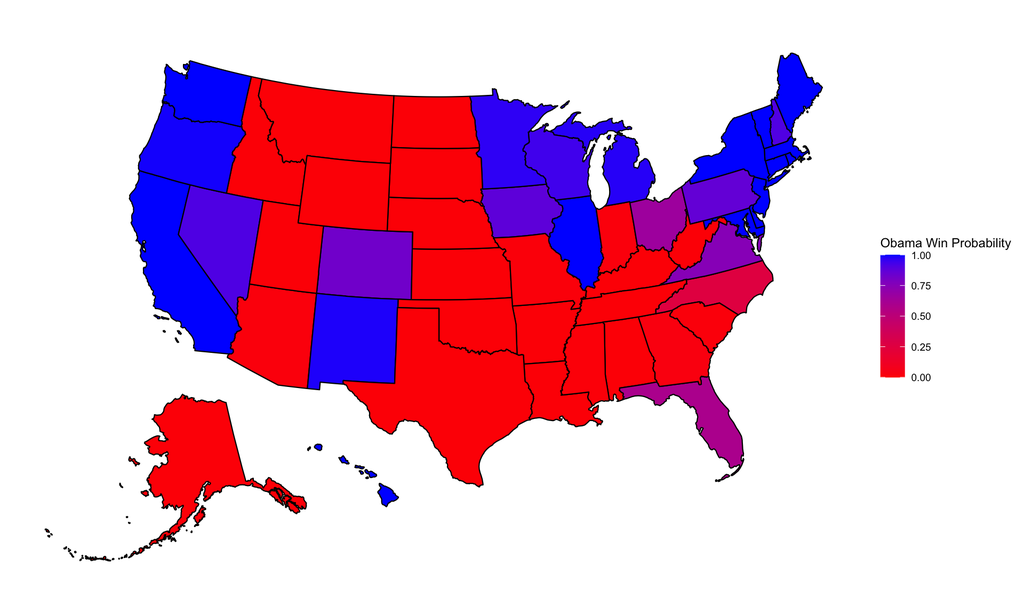

Probabilities of Obama winning by state

## Simulate the probability of Obama winning the election.

Calculate the probability of Obama having 270 EV or more

```r
sim.election <- function(win.probs) {
    winner <- rbinom(51, 1, win.probs$Obama)
    sum(win.probs$EV * winner)
}

sim.EV <- replicate(10000, sim.election(win.probs))
oprob <- sum(sim.EV >= 270)/length(sim.EV)
oprob
```

```
[1] 0.9631
```

## Plot the distribution of the simulated electoral votes for Obama.

```r
library(lattice)
# Lattice Graph
densityplot(sim.EV, plot.points = "rug", xlab = "Electoral Votes for Obama",
    panel = function(x, ...) {
        panel.densityplot(x, ...)
        panel.abline(v = 270)
        panel.text(x = 285, y = 0.01, "270 EV to Win")
        panel.abline(v = 332)
        panel.text(x = 347, y = 0.01, "Actual Obama")
}, main = "Electoral College Results Probability")
```

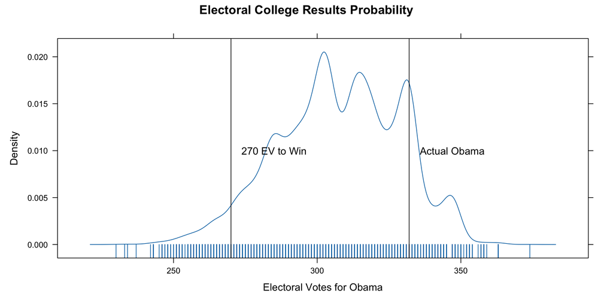

## Beta distribution

- A law on a single probability, $\theta \in (0,1)$. Coin, poll share, conversion rate.
  $$f(\theta) = \frac{\Gamma(\alpha+\beta)}{\Gamma(\alpha)\Gamma(\beta)}\,\theta^{\alpha-1}(1-\theta)^{\beta-1}.$$
- $\alpha$ and $\beta$ are positive. Mean $\alpha/(\alpha+\beta)$.
- $\mathrm{Beta}(1,1)$ is uniform. Larger $\alpha+\beta$: tighter around the mean.
- Two shares that sum to 1: Obama vs not Obama is a Beta. Three shares need Dirichlet.

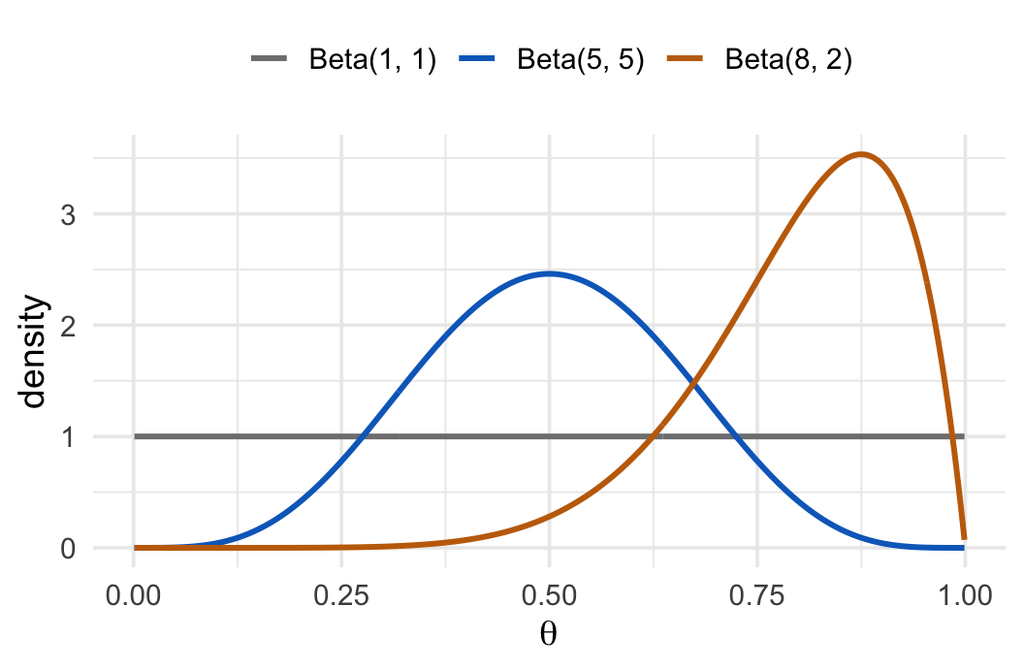

## Dirichlet Distribution

- Same idea for $k$ shares that sum to 1. Poll: Republican, Democrat, other.
- $k=2$ is Beta: $\mathrm{Dirichlet}(\alpha,\beta)=\mathrm{Beta}(\alpha,\beta)$.
- Parameters $\alpha=(\alpha_1,\ldots,\alpha_k)$, each $\alpha_i>0$.
- Support: $x_i\ge 0$ and $\sum_i x_i=1$.
  $$f(x\mid\alpha)=\frac{\Gamma(\sum_i\alpha_i)}{\prod_i\Gamma(\alpha_i)}\prod_{i=1}^k x_i^{\alpha_i-1}.$$

## Dirichlet Distribution

**Application in Election Forecasting:**

- Models uncertainty in polling percentages
- Three components: Republican, Democrat, Undecided
- Parameters reflect poll sample sizes and percentages
- Generates probability distributions for each candidate’s support

**Why Use Dirichlet for Polling?**

- Naturally handles the constraint that percentages sum to 100%
- Incorporates polling uncertainty
- Allows for Monte Carlo simulation of election outcomes
- Conjugate prior for multinomial likelihood (Bayesian convenience)

## 2008 Election Example

Results of recent state polls in the 2008 United States Presidential Election between Barack Obama and John McCain.

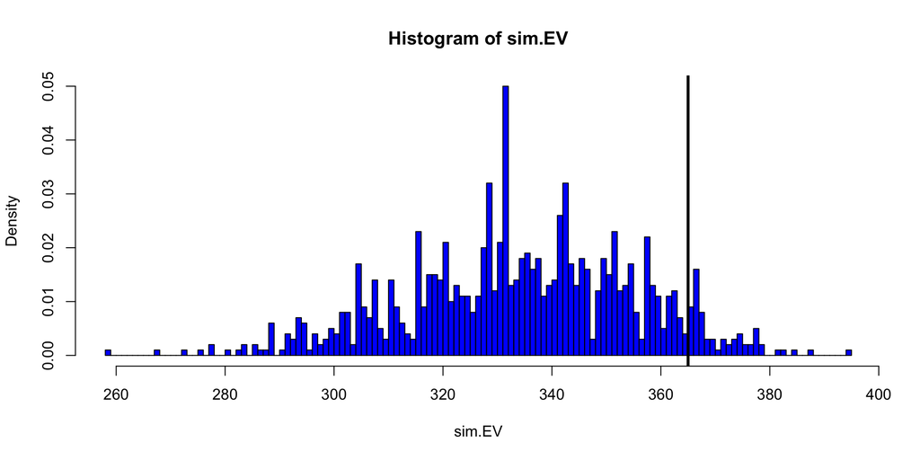

```r
# Source: LearnBayes library
#| fig-height: 6
election.2008 = read.csv("data/election2008.csv")
attach(election.2008)

##  Dirichlet simulation

prob.Obama = function(j)
 {
 p=rdirichlet(5000,500*c(M.pct[j],O.pct[j],100-M.pct[j]-O.pct[j])/100+1)
 mean(p[,2]>p[,1])
 }

## sapply function to compute Obama win prob for all states

Obama.win.probs=sapply(1:51,prob.Obama)

##  sim.EV function

sim.election = function()
 {
 winner = rbinom(51,1,Obama.win.probs)
 sum(EV*winner)
 }

sim.EV = replicate(1000,sim.election())

## histogram of simulated election
hist(sim.EV,min(sim.EV):max(sim.EV),col="blue",prob=T)
abline(v=365,lwd=3)   # Obama received 365 votes
text(375,30,"Actual \n Obama \n total")
```

# Estimation

## Case Study: Emissions of Alpha Particles

- Berkson (1966) conducted a careful analysis of data obtained from the National Bureau of Standards.
- The source of the alpha particles was americium 241.
- n is the number of counts that were observed in 1207 intervals, each of length 10 sec.
- In 18 of the 1207 intervals, there were 0, 1, or 2 counts; in 28 of the intervals there were 3 counts, etc.

```r
d = read.csv("data/berkson.csv")
head(d)
```

```
  n Observed Expected
1 1       18     12.2
2 3       28     27.0
3 4       56     56.5
4 5      105     94.9
5 6      126    132.7
6 7      146    159.1
```

```r
lmb = sum(d$Observed*d$n)/sum(d$Observed)/10 # mean emission rate
lmb
```

```
[1] 0.8354598
```

## Case Study: Emissions of Alpha Particles

To fit a Poisson distribution, we need to estimate its single parameter, λ.

$$P(X=k) = \frac{\lambda^k e^{-\lambda}}{k!}$$

A natural choice for the estimate, $\hat{\lambda}$, is the sample mean of the observed counts.

- **Estimate:** A value for an unknown parameter based on data.
- **Sampling Distribution:** The probability distribution of an estimate if the experiment were repeated. The spread of this distribution indicates the estimate’s variability.

We will explore the rationale for this choice and how to assess its reliability.

## Fitting a Poisson Distribution

Let’s plot the observed and expected frequencies.

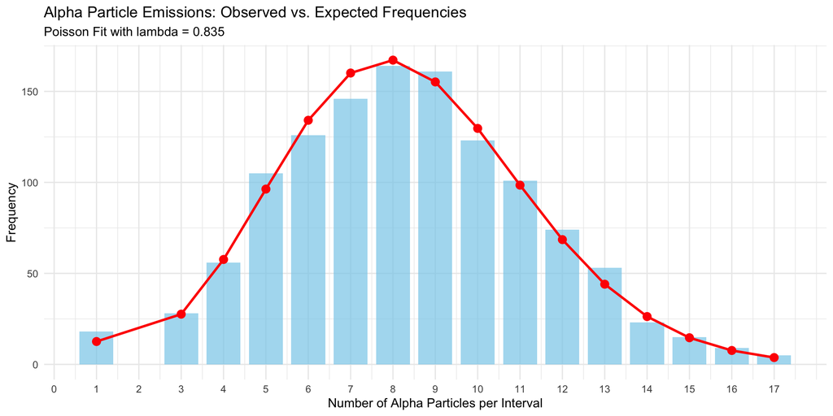

```r
#| fig-width: 8
#| fig-height: 5
#| code-fold: true

expected_counts = dpois(0:17, lmb*10)*1207 # expected count
expected_counts = c(sum(expected_counts[1:3]), expected_counts[4:18])


# Create a data frame for plotting
results <- data.frame(
  Particles = d$n,
  Observed = d$Observed,
  Expected = expected_counts
)

# Plotting
library(ggplot2)
ggplot() +
  geom_bar(data = results, aes(x = Particles, y = Observed), stat = "identity", fill = "skyblue", alpha = 0.7, width=0.8) +
  geom_line(data = results, aes(x = Particles, y = Expected), color = "red", linewidth=1) +
  geom_point(data = results, aes(x = Particles, y = Expected), color = "red", size=3) +
  scale_x_continuous(breaks = 0:17) +
  labs(title = "Alpha Particle Emissions: Observed vs. Expected Frequencies",
       subtitle = paste("Poisson Fit with lambda =", round(lmb, 3)),
       x = "Number of Alpha Particles per Interval",
       y = "Frequency") +
  theme_minimal()
```

## Sampling Distribution of Estimates

- If the experiment were to be repeated, the counts would be different and the estimate of λ would be different
- It is thus appropriate to regard the estimate of λ as a **random variable** which has a probability distribution referred to as its **sampling distribution**
- The situation is entirely analogous to tossing a coin 10 times and regarding the number of heads as a binomially distributed random variable

## Normal Distribution

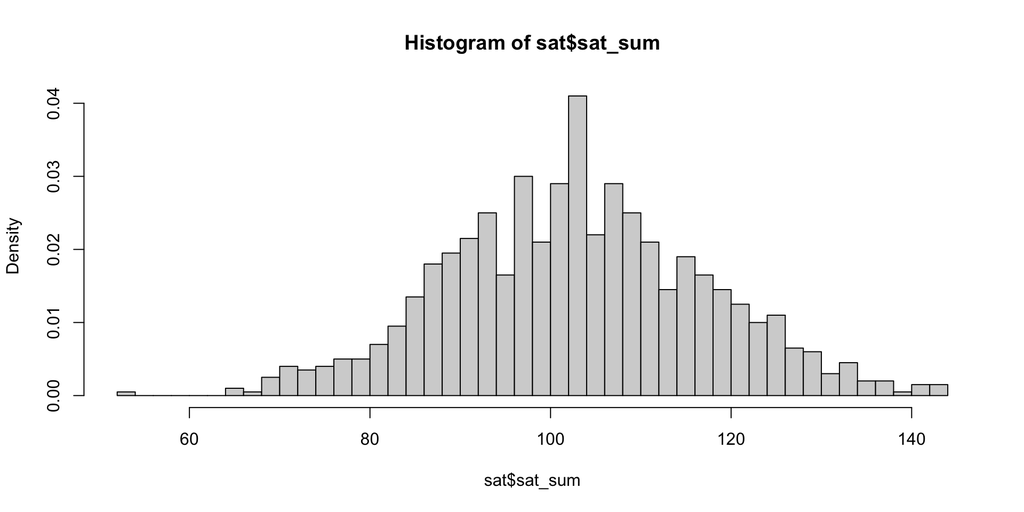

```r
# Data from https://www.openintro.org/data/index.php?data=satgpa&utm_source=chatgpt.com
sat = read.csv("data/satgpa.csv")
hist(sat$sat_sum, breaks = 40, freq=F)
```

## Normal Distribution

The density of normal is
$$f(x) = \frac{1}{\sqrt{2\pi\sigma^2}} e^{-\frac{(x-\mu)^2}{2\sigma^2}}$$

## Fit Normal Distribution

```r
mu_hat = mean(sat$sat_sum)
sigma2_hat = var(sat$sat_sum)
sigma_hat = sqrt(sigma2_hat)
```

Now Plot the histogram and the fitted normal curve.

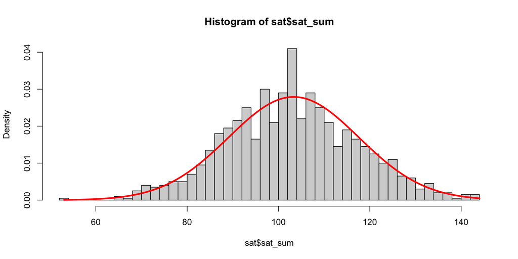

```r
# Draw bell curve on top of histogram
x = seq(min(sat$sat_sum), max(sat$sat_sum), length.out = 100)
y = dnorm(x, mean = mu_hat, sd = sigma_hat)
hist(sat$sat_sum, breaks = 40, freq=F)
lines(x, y, col = "red", lwd=3)
```

## Parameter Estimation: The Core Idea

- We treat observed data ($x_1, x_2, \dots, x_n$) as realizations of a random variable ($X_1, X_2, \dots, X_n$).
- The joint distribution of these random variables depends on an unknown parameter, $\theta$.
- Often, we assume the $X_i$ are independent and identically distributed (i.i.d.) from a distribution $f(x|\theta)$.
- An **estimate** of $\theta$ is a function of the data, and thus is itself a random variable with a sampling distribution.

We will look at two general methods for creating estimates: 1. The Method of Moments 2. The Method of Maximum Likelihood

## The Method of Moments

This method equates sample moments with the theoretical moments of the distribution, which are functions of the parameters.

**Procedure:**

1. Calculate the first few theoretical moments of the distribution, $E(X^k)$, in terms of the parameters.
2. Express the parameters as functions of these moments.
3. Replace the theoretical moments with the sample moments, $\hat{\mu}_k = \frac{1}{n}\sum_{i=1}^n X_i^k$, to get the estimates.

## Method of Moments: Poisson Example

For a Poisson distribution, the first theoretical moment is the mean:
$$E(X) = \lambda$$

The first sample moment is the sample mean:
$$\hat{\mu}_1 = \bar{X}$$

Equating them gives the method of moments estimate for λ:
$$\hat{\lambda} = \bar{X}$$

This is precisely what was done in the alpha particle example.

## Method of Moments: Normal Distribution

For a Normal distribution, the first two theoretical moments are:
$$E(X) = \mu$$
$$E(X^2) = \mu^2 + \sigma^2$$
Solving for the parameters gives:
$$\mu = E(X)$$
$$\sigma^2 = E(X^2) - [E(X)]^2$$
The method of moments estimates are found by replacing theoretical moments with sample moments:
$$\hat{\mu} = \bar{X}$$
$$\hat{\sigma}^2 = \frac{1}{n}\sum_{i=1}^n X_i^2 - \bar{X}^2 = \frac{1}{n}\sum_{i=1}^n (X_i - \bar{X})^2$$

## Method of Moments: Body Temperature Example

Let’s fit a normal distribution to human body temperature data. We’ll use the method of moments to estimate μ and σ and visualize the fit.

```r
# Load the body temperature data
bodytemp <- read.csv("data/bodytemp.txt")
temperatures <- bodytemp$temperature

# Method of Moments estimates
mu_hat <- mean(temperatures)
# Note: R's var() function uses the n-1 denominator for an unbiased estimate.
# The strict method of moments uses n. The difference is negligible for large n.
sigma2_hat <- var(temperatures) * (length(temperatures)-1) / length(temperatures)
sigma_hat <- sqrt(sigma2_hat)

print(paste("Estimated mu:", round(mu_hat, 2)))
```

```
[1] "Estimated mu: 98.25"
```

```r
print(paste("Estimated sigma:", round(sigma_hat, 2)))
```

```
[1] "Estimated sigma: 0.73"
```

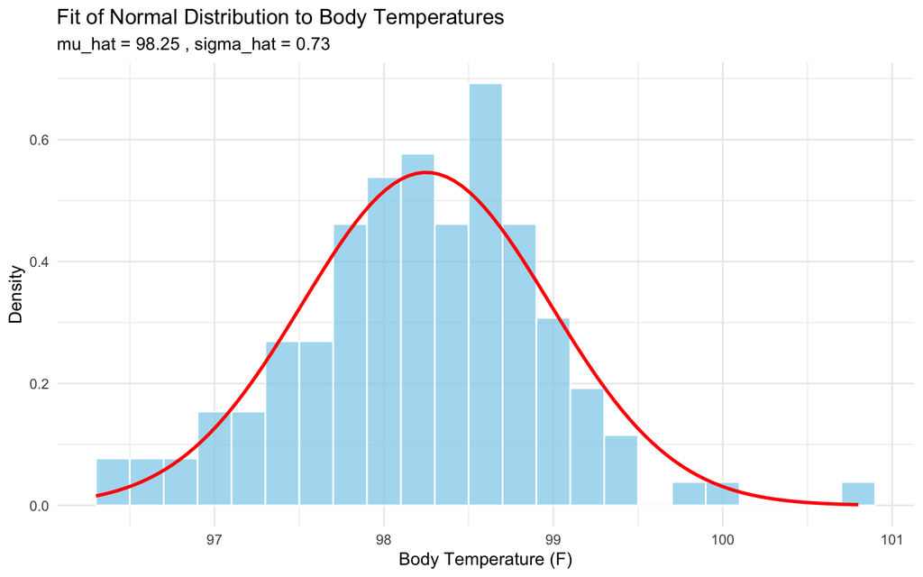

```r
# Plotting the histogram and the fitted normal curve
library(ggplot2)
ggplot(data.frame(x = temperatures), aes(x = x)) +
  geom_histogram(aes(y = after_stat(density)), binwidth = 0.2, fill = "skyblue", color = "white", alpha = 0.7) +
  stat_function(fun = dnorm, args = list(mean = mu_hat, sd = sigma_hat), color = "red", size = 1) +
  labs(title = "Fit of Normal Distribution to Body Temperatures",
       subtitle = paste("mu_hat =", round(mu_hat, 2), ", sigma_hat =", round(sigma_hat, 2)),
       x = "Body Temperature (F)",
       y = "Density") +
  theme_minimal()
```

## Error = bias + variance

An estimate is wrong for two reasons.

- Bias: even with infinite data you are pointed at the wrong place. $E(\hat\theta)-\theta$ does not go to zero.
- Variance: a new sample would move the answer. That is the sampling distribution we just discussed.
- Expected squared error splits:
  $$\mathrm{MSE}(\hat\theta)=\mathrm{Bias}(\hat\theta)^2+\mathrm{Var}(\hat\theta)$$
- The course will spend weeks on the second term. In the data you actually meet, the first term is usually the one that matters.

[figure not shown]

Low/high bias vs low/high variance

## Courses teach variance. Life is bias.

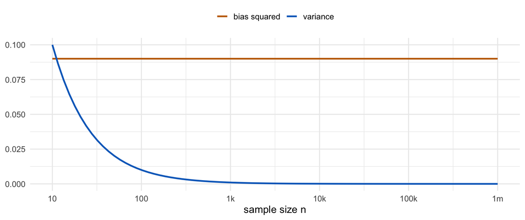

Internet-scale $n$ makes the blue line vanish.

- The orange line is the error that is left.
- A tight interval around the wrong number is not a good estimate.
- Week 10 is the other bias-variance: model complexity. This one is the data.

## Biased data

- The sample is not the population you will decide for. More rows of the same kind do not fix that.
- Who answered, who clicked, who left a review, who got scraped into the training set.
- Literary Digest, 1936: two million replies, Landon by a landslide. Roosevelt won. The list was phone books and car registrations.
- App-store stars, Twitter as “the public,” click-through as “what people want.”
- The instrument is off. The labeler is tired. You measured the easy cases. Wald: you only see the planes that came back.
- Write the sentence: how did a row get here? If you cannot, you do not know what $\hat\theta$ is estimating.

## How to detect it

- Bias does not announce itself as a wide interval. The interval is often tiny.
- Compare margins to something you trust: a census, an administrative file, a small paid panel, last year’s audited count.
- Split by source, week, device, geography. If the answer moves, a group is missing or over-weighted.
- A number that cannot be: turnout over 100%, a mean that the mechanism cannot produce.
- Add more of the same data. If the estimate does not move and you still doubt the story, that is bias, not precision.
- Ask who is absent. The missing rows are the bias.
- Variance you see by resampling. Bias you see by changing who is in the sample.

## How to treat it

- You cannot average it away. Do not buy a larger pull from the same hose.
- Get the missing group, or narrow the claim to the population you actually have.
- Reweight only when you know who is missing and by how much. Otherwise you are inventing a census.
- Measure the same thing another way: a different instrument, a different window, a designed sample.
- If the decision needs an unbiased number, design the data. A survey with a frame. An experiment. A smaller honest sample beats a large biased one.
- Report the selection story with the number. A correct figure with the wrong population is still a wrong answer.

## Case: Women’s Health Initiative

- Hormone replacement was supposed to protect the heart.
- Observational cohorts, including the Nurses’ Health Study, found that women on estrogen had about a third the coronary disease of women who were not.
- Guidelines followed. By 2001 about 15 million women a year were filling prescriptions.
- The rows were women who had chosen the pill: they also exercised, kept appointments, had money. A tight interval around the wrong $\hat\theta$.

## WHI: how they treated it

- They treated the bias by changing who is in the sample.
- They did not buy a larger observational pull, and they did not reweight it until they knew who starts and who stays on the drug.
- Randomized 16,608 postmenopausal women to estrogen plus progestin or placebo. Stopped early.
- Coronary disease went up, about 29 percent, not down.
- Later new-user analyses of the observational sample move toward the trial, but only after the mechanism is named.
- Read [Shrank, Patrick, and Brookhart, JGIM 2011](https://pmc.ncbi.nlm.nih.gov/articles/PMC3077477/) (open). The trial is Rossouw et al., JAMA 2002. Catalog of Bias: [healthy users](https://catalogofbias.org/biases/healthy-user-bias/).

## Cumulative Distribution Function (CDF)

The CDF of a random variable $X$, denoted as $F(x)$, is defined as:
$$F(x) = P(X \leq x)$$

**Key Properties:**

- Monotonically increasing: if $a \leq b$, then $F(a) \leq F(b)$
- Always between 0 and 1: $0 \leq F(x) \leq 1$
- $\lim_{x \to -\infty} F(x) = 0$ and $\lim_{x \to \infty} F(x) = 1$

## CDF for Discrete Random Variables

For a discrete random variable, the CDF is a step function:
$$F(x) = \sum_{k: x_k \leq x} P(X = x_k)$$

**Example:** Rolling a six-sided die

- For $x < 1$: $F(x) = 0$
- For $1 \leq x < 2$: $F(x) = \frac{1}{6}$
- For $2 \leq x < 3$: $F(x) = \frac{2}{6}$
- …
- For $x \geq 6$: $F(x) = 1$

## CDF for Discrete Random Variables

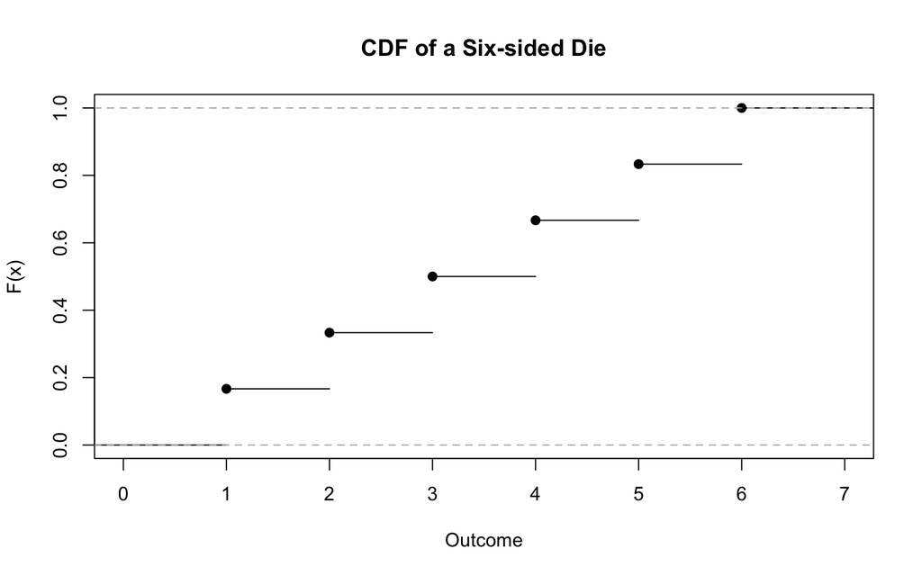

```r
plot(ecdf(1:6), main="CDF of a Six-sided Die", xlab="Outcome", ylab="F(x)")
```

## CDF for Continuous Random Variables

For a continuous random variable with PDF $f(x)$:
$$F(x) = \int_{-\infty}^x f(t) \, dt$$

**Relationship between PDF and CDF:**
$$f(x) = \frac{dF(x)}{dx}$$

**Probability calculations:**
$$P(a < X \leq b) = F(b) - F(a)$$

## Example: Uniform Distribution CDF

For uniform distribution on $[0,1]$ with PDF:
$$f(x) = \begin{cases}
1 & \text{if } 0 \leq x \leq 1 \\
0 & \text{otherwise}
\end{cases}$$

The CDF is:
$$F(x) = \begin{cases}
0 & \text{if } x < 0 \\
x & \text{if } 0 \leq x \leq 1 \\
1 & \text{if } x > 1
\end{cases}$$

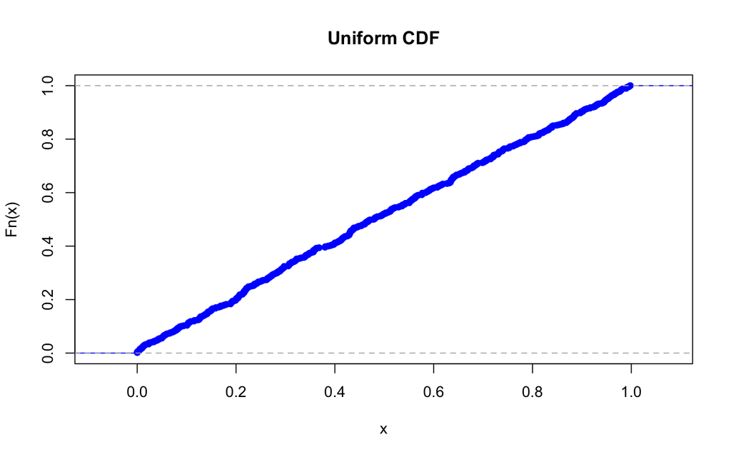

CDF of uniform distribution

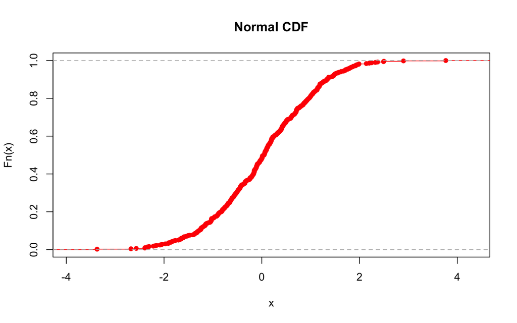

CDF of normal distribution

```r
plot(ecdf(runif(500)), main="Uniform CDF", col="blue", pch=16)
plot(ecdf(rnorm(500)), main="Normal CDF", col="red", pch=16)
```

## Applications of CDF

**1. Probability Calculations:**

- $P(X \leq a) = F(a)$
- $P(X > a) = 1 - F(a)$
- $P(a < X \leq b) = F(b) - F(a)$

**2. Percentiles and Quantiles:**

- The $p$-th percentile is $x_p$ such that $F(x_p) = p/100$
- Median: $F^{-1}(0.5)$

**3. Random Number Generation:**

- Inverse transform method: If $U \sim \text{Uniform}(0,1)$, then $X = F^{-1}(U)$ has CDF $F$

## Inverse CDF Method

**Algorithm for generating random samples:**

1. **Step 1:** Draw $U \sim \text{Uniform}[0,1]$
2. **Step 2:** Set $X = F^{-1}(U)$

**Why it works:** If $U$ is uniform on $[0,1]$, then $F^{-1}(U)$ has the desired distribution $F$.

This method is particularly useful when:

- The inverse CDF can be computed analytically
- We need exact samples from a known distribution

## Normal Distribution CDF

For a normal random variable $X \sim N(\mu, \sigma^2)$, the CDF is:
$$F(x) = P(X \leq x) = \int_{-\infty}^x \frac{1}{\sigma\sqrt{2\pi}} e^{-\frac{(t-\mu)^2}{2\sigma^2}} dt$$

**No closed-form solution exists** - must use numerical methods or tables.

**Standard Normal CDF:** When $\mu = 0, \sigma = 1$:
$$\Phi(z) = \int_{-\infty}^z \frac{1}{\sqrt{2\pi}} e^{-\frac{t^2}{2}} dt$$

**Standardization:** $F(x) = \Phi\left(\frac{x-\mu}{\sigma}\right)$

## Standard Normal CDF Properties

**Key Properties of $\Phi(z)$:**

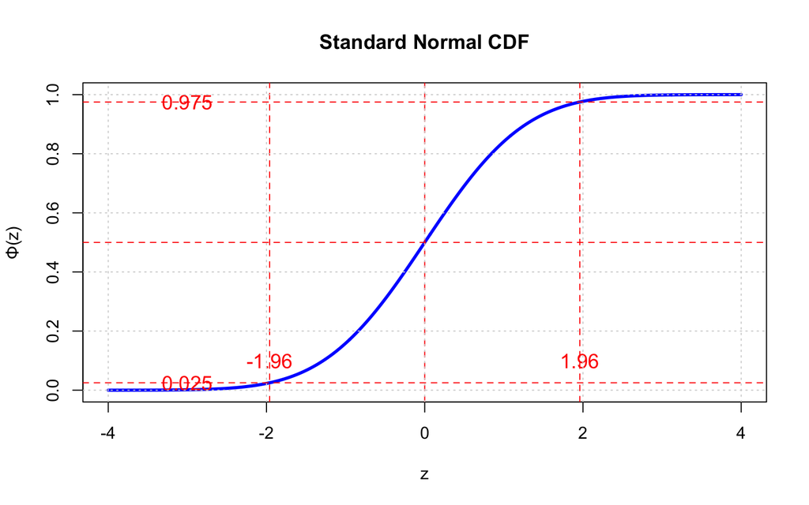

Standard Normal CDF with key values highlighted

```r
z <- seq(-4, 4, length.out = 1000)
phi_z <- pnorm(z)

plot(z, phi_z, type = "l", lwd = 3, col = "blue",
     xlab = "z", ylab = "Φ(z)",
     main = "Standard Normal CDF")

# Add horizontal lines for key probabilities
abline(h = c(0.025, 0.5, 0.975), col = "red", lty = 2)
abline(v = c(-1.96, 0, 1.96), col = "red", lty = 2)

# Add labels
text(-1.96, 0.1, "-1.96", col = "red", cex = 1.2)
text(1.96, 0.1, "1.96", col = "red", cex = 1.2)
text(-3, 0.975, "0.975", col = "red", cex = 1.2)
text(-3, 0.025, "0.025", col = "red", cex = 1.2)

grid()
```

## Normal CDF: Practical Applications

**1. Probability Calculations:**
$$P(a < X < b) = \Phi\left(\frac{b-\mu}{\sigma}\right) - \Phi\left(\frac{a-\mu}{\sigma}\right)$$

**2. Confidence Intervals:**

- 68% of data within $\mu \pm \sigma$ (between -1 and 1 standard deviations)
- 95% of data within $\mu \pm 1.96\sigma$
- 99% of data within $\mu \pm 2.58\sigma$

**3. Quality Control:**

- Process capability indices
- Control chart limits
- Defect rate calculations

## Example: SAT Scores

SAT scores are approximately $N(1000, 200^2)$. Let’s calculate some probabilities:

```r
mu_sat <- 1000
sigma_sat <- 200

# Calculate key probabilities
prob_above_1200 <- 1 - pnorm(1200, mu_sat, sigma_sat)
prob_between_800_1200 <- pnorm(1200, mu_sat, sigma_sat) - pnorm(800, mu_sat, sigma_sat)

cat("P(SAT > 1200) =", round(prob_above_1200, 3), "\n")
```

```
P(SAT > 1200) = 0.159
```

```r
cat("P(800 < SAT < 1200) =", round(prob_between_800_1200, 3), "\n")
```

```
P(800 < SAT < 1200) = 0.683
```

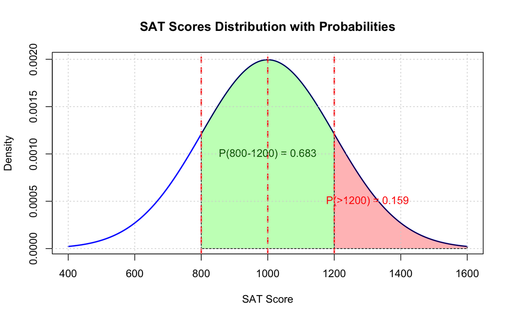

```r
# Visualization
x <- seq(400, 1600, length.out = 1000)
y <- dnorm(x, mu_sat, sigma_sat)

plot(x, y, type = "l", lwd = 2, col = "blue",
     xlab = "SAT Score", ylab = "Density",
     main = "SAT Scores Distribution with Probabilities")

# Shade areas
x_above <- seq(1200, 1600, length.out = 100)
y_above <- dnorm(x_above, mu_sat, sigma_sat)
polygon(c(1200, x_above, 1600), c(0, y_above, 0),
         col = rgb(1, 0, 0, alpha = 0.3))

x_between <- seq(800, 1200, length.out = 100)
y_between <- dnorm(x_between, mu_sat, sigma_sat)
polygon(c(800, x_between, 1200), c(0, y_between, 0),
         col = rgb(0, 1, 0, alpha = 0.3))

# Add vertical lines
abline(v = c(800, 1000, 1200), col = "red", lty = 2, lwd = 2)

# Add labels
text(1300, 0.0005, paste("P(>1200) =", round(prob_above_1200, 3)), col = "red")
text(1000, 0.001, paste("P(800-1200) =", round(prob_between_800_1200, 3)), col = "darkgreen")

grid()
```

## Normal CDF in R

**Key R functions for Normal CDF:**

```r
# Standard normal CDF
pnorm(1.96)  # Φ(1.96) ≈ 0.975
```

```
[1] 0.9750021
```

```r
# General normal CDF
pnorm(1200, mean = 1000, sd = 200)  # P(X ≤ 1200)
```

```
[1] 0.8413447
```

```r
# Quantiles (inverse CDF)
qnorm(0.975)  # z such that Φ(z) = 0.975
```

```
[1] 1.959964
```

```r
qnorm(0.95, mean = 1000, sd = 200)  # 95th percentile of N(1000, 200²)
```

```
[1] 1328.971
```

```r
# Two-sided probabilities
pnorm(1.96) - pnorm(-1.96)  # P(-1.96 < Z < 1.96) ≈ 0.95
```

```
[1] 0.9500042
```

## Useful For

- **Hypothesis testing (p-values):** Calculate probabilities of observing data as extreme or more extreme than what was observed, assuming a null hypothesis is true
- **Confidence intervals:** Determine ranges of plausible values for population parameters based on sample data and desired confidence levels
- **Process control:** Monitor manufacturing or business processes by identifying when measurements fall outside expected ranges
- **Risk analysis:** Assess probabilities of extreme events in finance, insurance, and engineering applications
- **Quality control:** Evaluate whether products meet specifications by calculating defect rates and acceptance probabilities
- **Medical diagnostics:** Determine reference ranges for biomarkers and assess probability of disease given test results
- **A/B testing:** Compare conversion rates between different website versions or marketing strategies
- **Portfolio optimization:** Calculate value-at-risk and expected returns in financial modeling

## Quantile Function: Definition and Intuition

The **quantile function** (also called the inverse CDF) gives the value $x$ such that the probability of the random variable being less than or equal to $x$ is a specified probability $p$.

- **Definition:** For a random variable $X$ with CDF $F(x)$, the quantile function $Q(p)$ is:
  $$Q(p) = \inf \{ x : F(x) \geq p \}$$
- **Interpretation:** $Q(p)$ is the value below which a proportion $p$ of the data falls.
- **Special cases:**
  - $Q(0.5)$ is the median
  - $Q(0.25)$ and $Q(0.75)$ are the first and third quartiles

**Why is it useful?** - Summarizes distributions (e.g., percentiles, medians) - Used in constructing confidence intervals and tolerance intervals - Important in risk analysis (e.g., Value-at-Risk in finance)

## Quantile Function in R: Examples

**R function:** `qnorm()` for the normal distribution (and `q*` for other distributions)

```r
qnorm(0.975)  # 97.5th percentile of standard normal
```

```
[1] 1.959964
```

```r
qnorm(0.95, mean = 1000, sd = 200)  # 95th percentile of N(1000, 200²)
```

```
[1] 1328.971
```

```r
curve(qnorm(x), from = 0, to = 1, n = 200,
      xlab = "Probability (p)", ylab = "Quantile Q(p)",
      main = "Quantile Function of Standard Normal (qnorm)")
abline(h = 0, v = 0.5, col = "red", lty = 2)
```

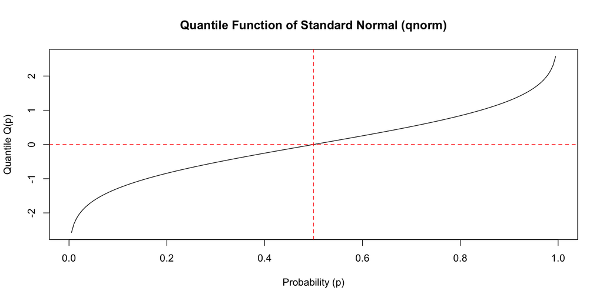

## Summary: PDF, CDF, Quantile Function

PDF

- **Definition:** Describes the relative likelihood for a random variable to take on a given value.
- **Notation:** $f(x)$
- **Properties:**
  - $f(x) \geq 0$
  - $\int_{-\infty}^{\infty} f(x) dx = 1$
- **Interpretation:** Height of the curve at $x$ (not a probability itself for continuous RVs).

CDF

- **Definition:** Probability that the random variable is less than or equal to $x$.
- **Notation:** $F(x) = P(X \leq x)$
- **Properties:**
  - $F(x)$ is non-decreasing
  - $F(-\infty) = 0$, $F(\infty) = 1$
- **Relation to PDF:** $F(x) = \int_{-\infty}^x f(t) dt$

Quantile

- **Definition:** Value $x$ such that $P(X \leq x) = p$
- **Notation:** $Q(p) = F^{-1}(p)$
- **Properties:**
  - $Q(0.5)$ = median
  - $Q(p)$ gives the $p$-th percentile
- **Use:** Find thresholds, percentiles, construct confidence intervals

## Likelihood Function for a Random Variable

Assume we observe $y_1, \ldots, y_n$ which are independent draws from a random variable $Y$ with probability density function $p(y | \theta)$ (normal, binomial, etc.).

**Likelihood Function:**
$$L(\theta) = \prod_{i=1}^n p(y_i | \theta)$$

**Log-likelihood Function:**
$$l(\theta) = \sum_{i=1}^n \log p(y_i | \theta)$$

Likelihood is a function of $\theta$ that measures how likely the observed data is given the parameter $\theta$.

## Maximum Likelihood Estimate

The maximum likelihood estimate of $\theta$ is the value of $\theta^*$ that maximizes the likelihood function.

$$\theta^* = \arg\max_{\theta} L(\theta)$$
Sometimes we use notations $\theta_{\text{MLE}}$ or simply $\hat \theta$ to denote the maximum likelihood estimate of $\theta$.

Or the log-likelihood function.
$$\theta^* = \arg\max_{\theta} l(\theta)$$

Logarithm is a monotonically increasing function, so the maximum likelihood estimate of $\theta$ is the same as the maximum log-likelihood estimate of $\theta$.

$$\theta^* = \arg\max_{\theta} L(\theta) = \arg\max_{\theta} l(\theta)$$

For exponential family RVs, it is easier to maximize the log-likelihood function.

Why?

## MLE for Normal Distribution

**For the normal distribution, maximum likelihood leads to least squares!**

Given $y_i \sim N(\mu, \sigma^2)$, here we have two parameters $\mu$ and $\sigma^2$.

$$l(\mu, \sigma^2) = \sum_{i=1}^n \log p(y_i | x_i, \mu, \sigma^2) = \sum_{i=1}^n \log \frac{1}{\sqrt{2\pi\sigma^2}} \exp\left(-\frac{(y_i - \mu)^2}{2\sigma^2}\right)$$

**Expanding the normal log-likelihood:**
$$l(\mu, \sigma^2) = \sum_{i=1}^n \left[-\frac{1}{2}\log(2\pi\sigma^2) - \frac{(y_i - \mu)^2}{2\sigma^2}\right]$$

**Removing $\sigma^2$ and simplifying:**
$$l(\mu) = - \frac{1}{2\sigma^2}\sum_{i=1}^n (y_i - \mu)^2 + \text{constant}$$

## Maximizing likelihood = Minimizing sum of squared errors:

$$\mu^* = \arg\min_{\mu} \sum_{i=1}^n (y_i - \mu)^2$$

Take the derivative of $l(\mu)$ with respect to $\mu$ and set it to 0:
$$\frac{\partial l(\mu)}{\partial \mu} = 2\sum_{i=1}^n (y_i - \mu) = 0$$
$$\sum_{i=1}^n (y_i - \mu) = 0$$
$$\sum_{i=1}^n y_i = n\mu$$
$$\hat \mu = \frac{1}{n}\sum_{i=1}^n y_i$$

## Example: MLE for Normal Mean with Real Data

**Dataset:** SAT score for 1000 students

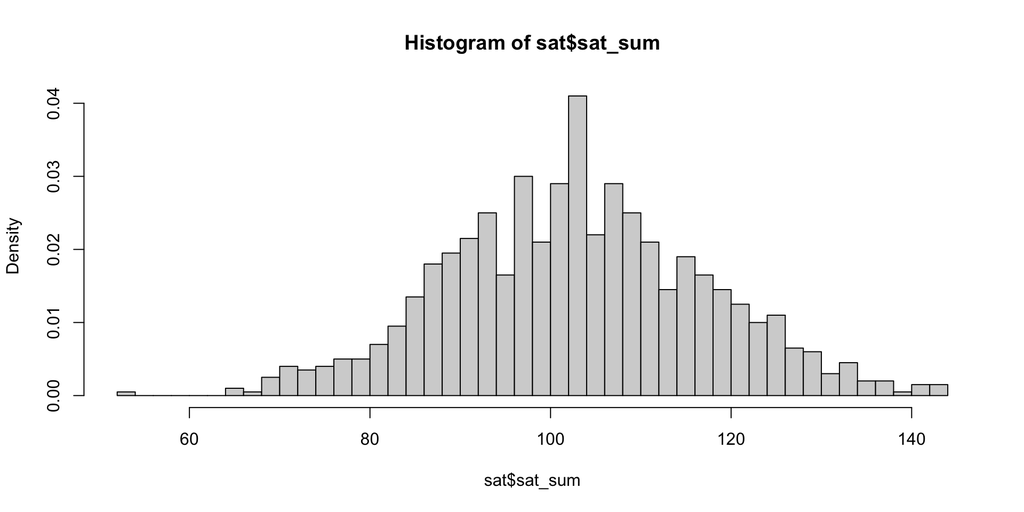

```r
# Data from https://www.openintro.org/data/index.php?data=satgpa&utm_source=chatgpt.com
sat = read.csv("data/satgpa.csv")
hist(sat$sat_sum, breaks = 40, freq=F)
```

## MLE Estimation

```r
mu_mle <- mean(sat$sat_sum)
sigma2_mle <- mean((sat$sat_sum - mu_mle)^2)
sigma_mle <- sqrt(sigma2_mle)
n <- nrow(sat)
# Print table
library(knitr)
results_table <- data.frame(
  Parameter = c("μ (mean)", "σ² (variance)", "σ (std dev)", "n (sample size)"),
  Value = c(round(mu_mle, 2), round(sigma2_mle, 2), round(sigma_mle, 2), n)
)
kable(results_table, caption = "Maximum Likelihood Estimates for Normal Distribution")
```

Maximum Likelihood Estimates for Normal Distribution

| Parameter | Value |
| --- | --- |
| μ (mean) | 103.33 |
| σ² (variance) | 203.92 |
| σ (std dev) | 14.28 |
| n (sample size) | 1000.00 |

## Draw bell curve on top of histogram

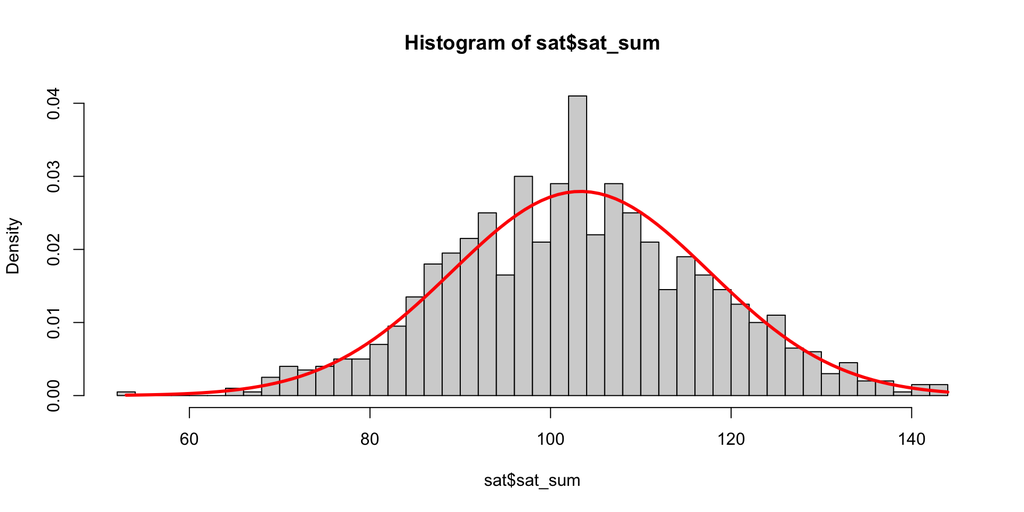

```r
# Draw bell curve on top of histogram
x = seq(min(sat$sat_sum), max(sat$sat_sum), length.out = 100)
y = dnorm(x, mean = mu_mle, sd = sigma_mle)
hist(sat$sat_sum, breaks = 40, freq=F)
lines(x, y, col = "red", lwd=3)
```

## Use Optimization to find MLE

```r
# Define negative log-likelihood function
neg_log_likelihood <- function(params, data) {
  mu <- params[1]
  sigma <- params[2]

  # Ensure sigma is positive
  if (sigma <= 0) return(Inf)

  # Calculate negative log-likelihood
  n <- length(data)
  -sum(dnorm(data, mean = mu, sd = sigma, log = TRUE))
}

# Optimize using built-in optimizer
result <- optim(c(50, 10), neg_log_likelihood, data = sat$sat_sum)
mu_optim <- result$par[1]
sigma_optim <- result$par[2]

# Create results table for optimization
optim_table <- data.frame(
  Parameter = c("μ", "σ"),
  Analytical = c(round(mu_mle, 2), round(sigma_mle, 2)),
  Optimized = c(round(mu_optim, 2), round(sigma_optim, 2)),
  Difference = c(round(abs(mu_mle - mu_optim), 6), round(abs(sigma_mle - sigma_optim), 6))
)
kable(optim_table, caption = "Comparison of Analytical vs Numerical Optimization Results")
```

Comparison of Analytical vs Numerical Optimization Results

| Parameter | Analytical | Optimized | Difference |
| --- | --- | --- | --- |
| μ | 103.33 | 103.33 | 0.000542 |
| σ | 14.28 | 14.28 | 0.002433 |

## Likelihood Function Visualization

**Create log-likelihood surface**

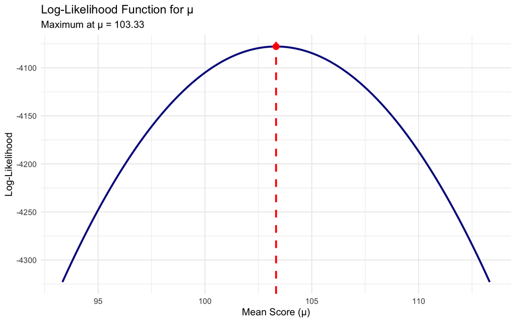

Log-likelihood surface for different values of μ

```r
# Create grid of mu values around the MLE
library(ggplot2)
mu_range <- seq(mu_mle - 10, mu_mle + 10, length.out = 100)
log_likelihood_values <- sapply(mu_range, function(mu) {
  -neg_log_likelihood(c(mu, sigma_mle), sat$sat_sum)
})

# Plot log-likelihood
likelihood_df <- data.frame(mu = mu_range, log_likelihood = log_likelihood_values)

ggplot(likelihood_df, aes(x = mu, y = log_likelihood)) +
  geom_line(color = "darkblue", linewidth = 1) +
  geom_vline(xintercept = mu_mle, color = "red", linetype = "dashed", linewidth = 1) +
  annotate("point", x = mu_mle, y = max(log_likelihood_values),
           color = "red", size = 3) +
  labs(title = "Log-Likelihood Function for μ",
       subtitle = paste("Maximum at μ =", round(mu_mle, 2)),
       x = "Mean Score (μ)",
       y = "Log-Likelihood") +
  theme_minimal()
```

# Central Limit Theorem

## Pyx Trial: Ancient Quality Control

**The Royal Mint Tradition (12th Century)**

- **Pyx**: Greek word “pyxis” = small box
- **Purpose**: Test quality of minted coins
- **Standards**: Weight and purity compliance

**Sir Isaac Newton’s Role (1696):**

- Warden then Master of the Mint
- Rigorous standards enforcement
- Combated counterfeiting and clipping
- Introduced milled edges on coins

## Pyx Trial: The Statistical Method

**The Process:**

1. Select $n$ coins from each batch
2. Place in the Pyx box
3. Calculate mean and variance for each attribute
4. Compare against legal tolerances

**Example:** 1 million coins minted, $n=100$ sample

- Legal weight tolerance: 0.05 grams
- True mean: 5.0 grams

```r
set.seed(17) # Kharlamov
allcoins = runif(1000000, 4.95, 5.05)
survey_sample = sample(allcoins, size = 100, replace = FALSE)
xbar = mean(survey_sample)
cat("Sample mean:", round(xbar, 4), "grams")
```

```
Sample mean: 4.9951 grams
```

## Pyx Trial: Multiple Samples

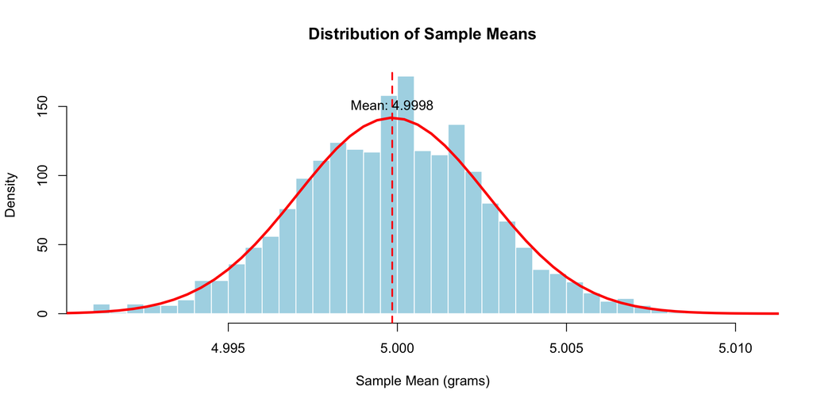

```r
# Simulate 2000 surveys
prep = replicate(2000, mean(sample(allcoins, size = 100, replace = FALSE)))
hist(prep, breaks = 30, freq = FALSE,
     main = "Distribution of Sample Means",
     xlab = "Sample Mean (grams)",
     col = "lightblue", border = "white")

# Overlay normal distribution
p = seq(4.9, 5.1, length.out = 500)
lines(p, dnorm(p, mean(prep), sd(prep)), col = "red", lwd = 3)

# Add statistics
abline(v = mean(prep), col = "red", lwd = 2, lty = 2)
text(mean(prep), max(dnorm(p, mean(prep), sd(prep))),
     paste("Mean:", round(mean(prep), 4)), pos = 3)
```

**Key Observation:** The red bell-curve (normal density) models the distribution well!

## Variance Decay: The Square Root Law

**The Fundamental Relationship**

**Standard Error decreases with $\sqrt{n}$:**
$$s_{\bar x} = \frac{s}{\sqrt{n}}$$

**This means:** To halve uncertainty, you need to quadruple sample size!

**The Math:**

- **Variance of mean:** $\mathrm{Var}(\bar X) = \frac{\sigma^2}{n}$
- **Standard error:** $s_{\bar x} = \frac{s}{\sqrt{n}}$
- **Confidence interval width:** $2 \times \frac{s}{\sqrt{n}}$

**Practical Implications:**

- Sample size 100 → Standard error = $s/10$
- Sample size 400 → Standard error = $s/20$ (half the uncertainty)
- Sample size 1600 → Standard error = $s/40$ (quarter the uncertainty)

## Variance Decay: Visual Demonstration

```r
# Simulate different sample sizes
set.seed(42)
true_mean = 5.0
true_sd = 0.1

sample_sizes = c(10, 25, 50, 100, 200, 400, 800, 1600)
n_sims = 1000

# Calculate standard errors for each sample size
se_values = true_sd / sqrt(sample_sizes)

# Simulate confidence interval widths
ci_widths = 2 * 1.96 * se_values

# Create visualization
par(mfrow = c(1, 2))

# Plot 1: Standard Error vs Sample Size
plot(sample_sizes, se_values,
     type = "b", lwd = 2, pch = 19, col = "blue",
     xlab = "Sample Size (n)", ylab = "Standard Error",
     main = "Standard Error vs Sample Size",
     log = "xy")
grid()

# Add theoretical curve
curve(true_sd / sqrt(x), from = 10, to = 1600,
      add = TRUE, col = "red", lwd = 2, lty = 2)
legend("topright", c("Observed", "Theoretical"),
       col = c("blue", "red"), lty = c(1, 2), lwd = 2)

# Plot 2: Confidence Interval Width
plot(sample_sizes, ci_widths,
     type = "b", lwd = 2, pch = 19, col = "green",
     xlab = "Sample Size (n)", ylab = "95% CI Width",
     main = "Confidence Interval Width vs Sample Size",
     log = "xy")
grid()

# Add theoretical curve
curve(2 * 1.96 * true_sd / sqrt(x), from = 10, to = 1600,
      add = TRUE, col = "red", lwd = 2, lty = 2)
legend("topright", c("Observed", "Theoretical"),
       col = c("green", "red"), lty = c(1, 2), lwd = 2)
```

```r
par(mfrow = c(1, 1))
```

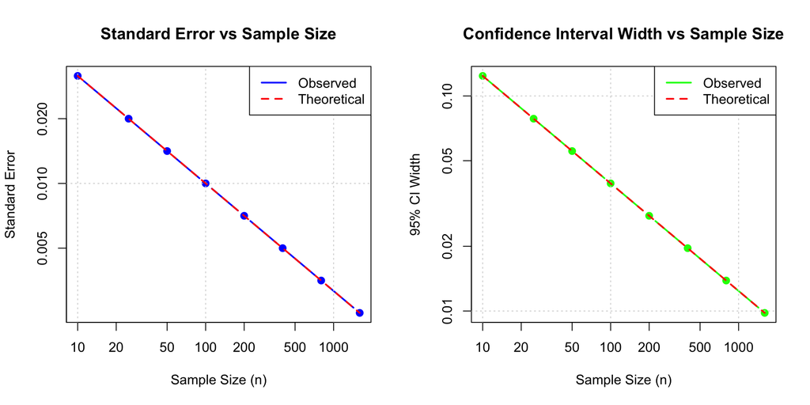

## Variance Decay: Real-World Example

**Scenario:** Quality control for coin weights

- Population standard deviation: $s = 0.1$ grams
- Target: 95% confidence interval width ≤ 0.02 grams

**Required sample sizes:**

```r
# Given parameters
target_width = 0.02
true_sd = 0.1
z_score = 1.96  # 95% confidence

# Calculate required sample size
required_n = (2 * z_score * true_sd / target_width)^2

cat("Required sample size:", ceiling(required_n), "\n")
```

```
Required sample size: 385
```

```r
cat("This gives CI width:", round(2 * z_score * true_sd / sqrt(required_n), 4), "grams\n")
```

```
This gives CI width: 0.02 grams
```

## CI width changes with sample size

```r
# Show how CI width changes with sample size
sample_sizes = c(100, 400, 1600, 6400)
ci_widths = 2 * z_score * true_sd / sqrt(sample_sizes)

cat("\nCI widths for different sample sizes:\n")
```

```
CI widths for different sample sizes:
```

```r
for(i in 1:length(sample_sizes)) {
  cat("n =", sample_sizes[i], "→ CI width =", round(ci_widths[i], 4), "grams\n")
}
```

```
n = 100 → CI width = 0.0392 grams
n = 400 → CI width = 0.0196 grams
n = 1600 → CI width = 0.0098 grams
n = 6400 → CI width = 0.0049 grams
```

## Central Limit Theorem

**The Most Powerful Theorem in Statistics**

**CLT states:** Given sufficiently large sample size, sample means are approximately normally distributed, regardless of population distribution shape.

**De Moivre-Laplace Theorem (1738):** For independent Rademacher variables $x_i$ with $P(x_i = \pm 1) = 1/2$:

$$\lim_{n\to\infty} P\left(a \le \frac{x_1+\cdots+x_n}{\sqrt{n}} \le b\right) = \int_a^b \frac{1}{\sqrt{2\pi}} e^{-x^2/2} dx$$